# How Latin America is Perceived in UN General Debates

Author

Wendy Chavez Tacuri

Published

May 6, 2024

# 1 Introduction

The idea behind this was to see which countries get the most attention and whether this can tell us something about their political or global relevance. I used Python to clean and analyze the text data, and then used R to visualize the results. Later on, I also explored sentiment analysis, to see not just how often countries are mentioned, but in what tone.

[figure not shown]

## 1.1 Visualization with ggplot2

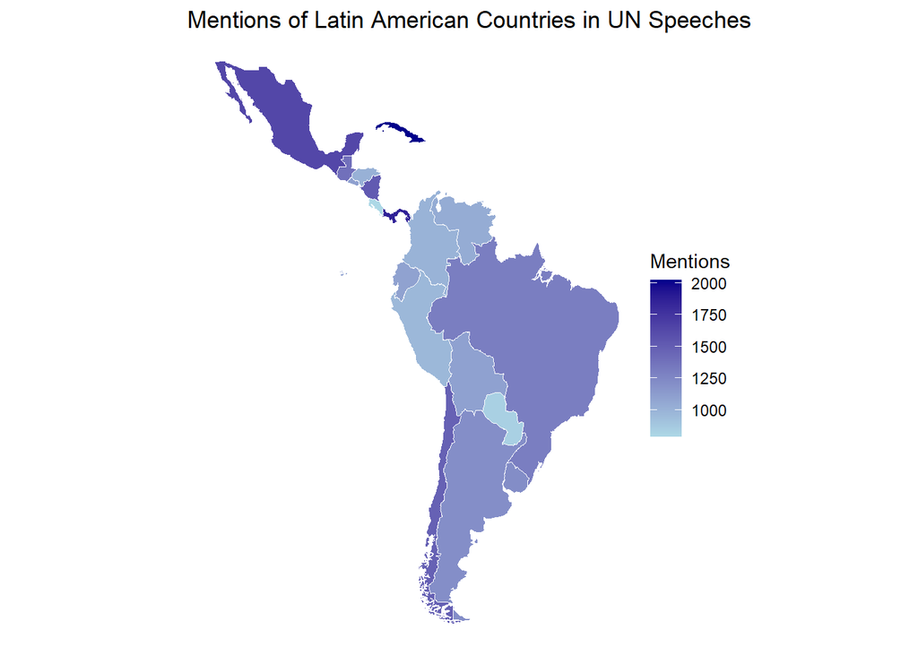

The darker shades mean more mentions.

In order to visualize how often Latin American countries are mentioned in UN General Debate speeches, I followed a process using Python and R for visualization.

I used Python to:

- Load and clean the dataset of UN speeches
- Define a list of Latin American countries
- Count how many times each country was mentioned in the text of all speeches
- Export this data into a CSV file

This resulted in a file:

latin_america_mentions.csv, containing two columns: country and mentions.

## 1.2 Mentions table

The following table shows each Latin American country sorted by the number of mentions.

| country | mentions |
| --- | --- |
| Cuba | 2023 |
| Panama | 1867 |
| Mexico | 1635 |
| Nicaragua | 1518 |
| Chile | 1479 |
| Guatemala | 1386 |
| Brazil | 1304 |
| Uruguay | 1213 |
| Argentina | 1206 |
| El Salvador | 1103 |
| Bolivia | 1095 |
| Ecuador | 1089 |
| Venezuela | 1034 |
| Honduras | 1005 |
| Colombia | 995 |
| Peru | 963 |
| Paraguay | 832 |
| Costa Rica | 786 |
| Dominican Rep. | 524 |

## 1.3 Mentions Bar Plot

This bar chart helps visualize the rankings of countries by how often they’re mentioned.

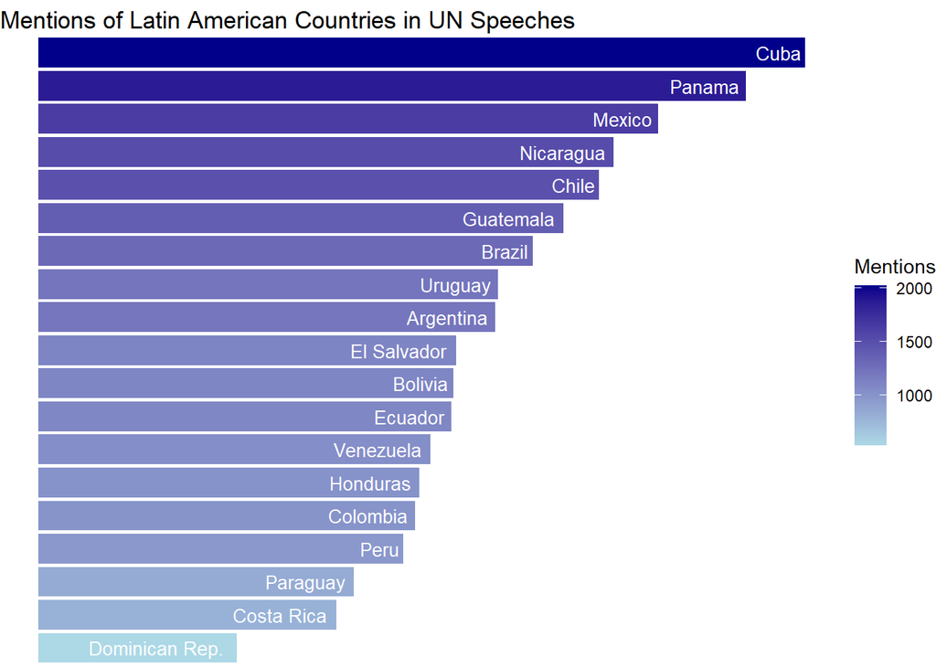

# 2 Textual Analysis

## 2.1 Word Frequency

Here, I identified the most commonly used words in UN speeches that mention Latin America to uncover dominant narratives or themes.

```
True
```

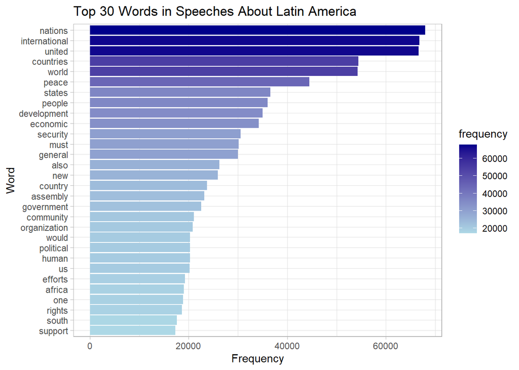

This chart shows the 30 most common words used in UN speeches that mention Latin America.

- The most frequent words are general terms like “nations”, “international”, and “countries”, which makes sense since these are speeches from the United Nations.
- We also see words like “peace”, “development”, “economic”, and “security”. These suggest that Latin America is often talked about in connection with global cooperation, economic growth, and peace efforts.

Other words like “people”, “support”, and “efforts” show a focus on helping communities or promoting shared values.

## 2.2 Wordclouds

To complement the frequency chart, I decided to create a wordcloud to offer a visual representation of the most frequently used words.

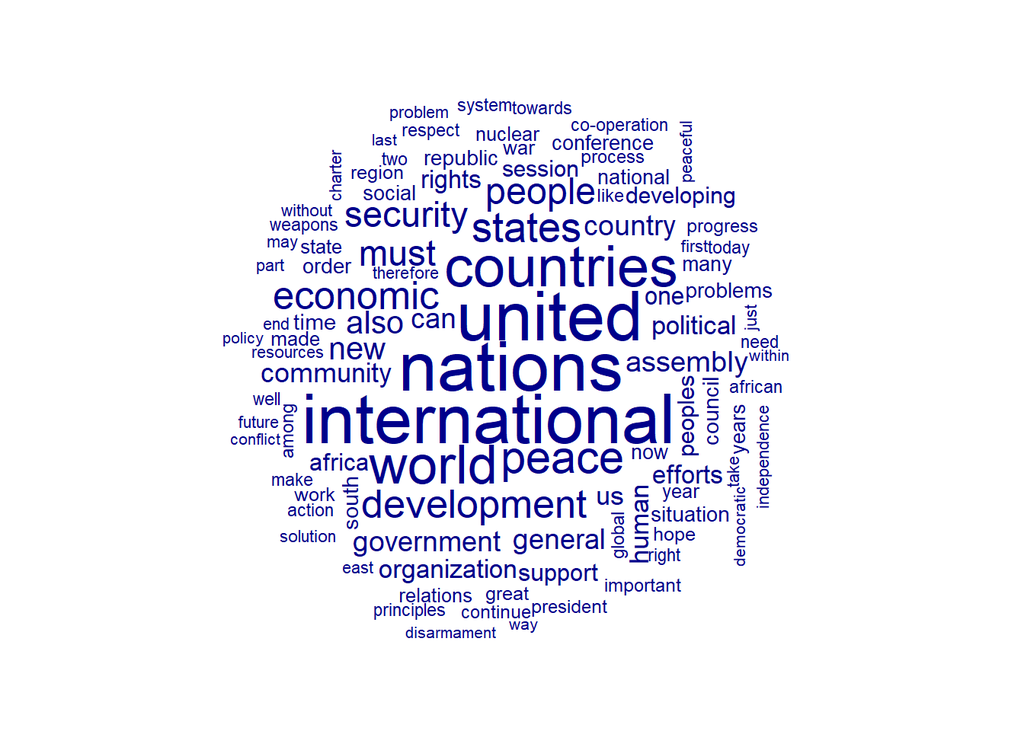

This wordcloud shows the most common terms found in UN speeches that mention Latin America.

Words like “nations”, “international”, “countries”, and “peace” are some of the largest, meaning they were used a lot.

This tells us that when Latin America is mentioned at the UN, it’s often in the context of international cooperation, global peace, and development.

It’s also interesting that words like “security”, “economic”, and “development” appear often, these show the main topics and concerns being discussed.

## 2.3 Sentiment analysis

In this section, I decided to take a different approach from the one we used in class; in fact, to keep things more efficient, I decided to use TextBlob, a Python library that assigns a basic polarity score to each text. This method doesn’t capture the full complexity of political language, but it still provides a useful overview of how the tone of speeches mentioning Latin America has evolved over time.

Later in the project, I did use GPT API to interpret the topics generated by LDA, since I felt that was a moment where a more interpretive model was really needed. But for this first sentiment trend, a lighter approach felt like a better fit.

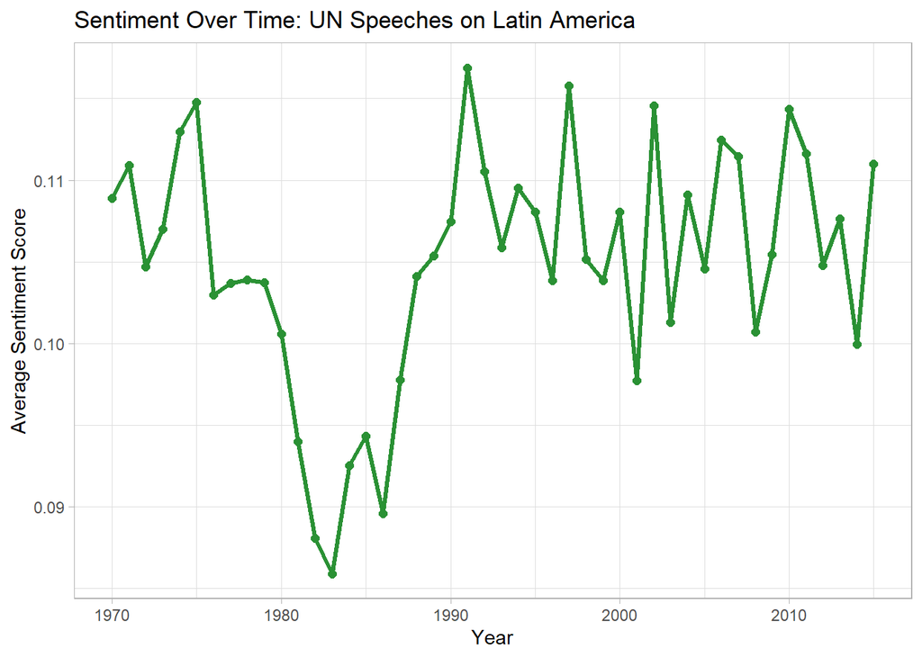

This is a line plot showing the average sentiment score of UN speeches that mention Latin America, for each year.

Here, as I said before, I used TextBlob This method automatically analyzes the text and gives a polarity score:

- +1 = very positive
- 0 = neutral
- –1 = very negative

In this chart:

Each dot is the average polarity of all speeches that mention Latin America in that year.

A score around 0.11 means speeches were generally slightly positive in tone.

## 2.4 Top Modeling LDA

While sentiment analysis helped capture the general tone of the speeches, I was also interested in uncovering the main topics that appeared repeatedly across the texts. To do this, I used LDA

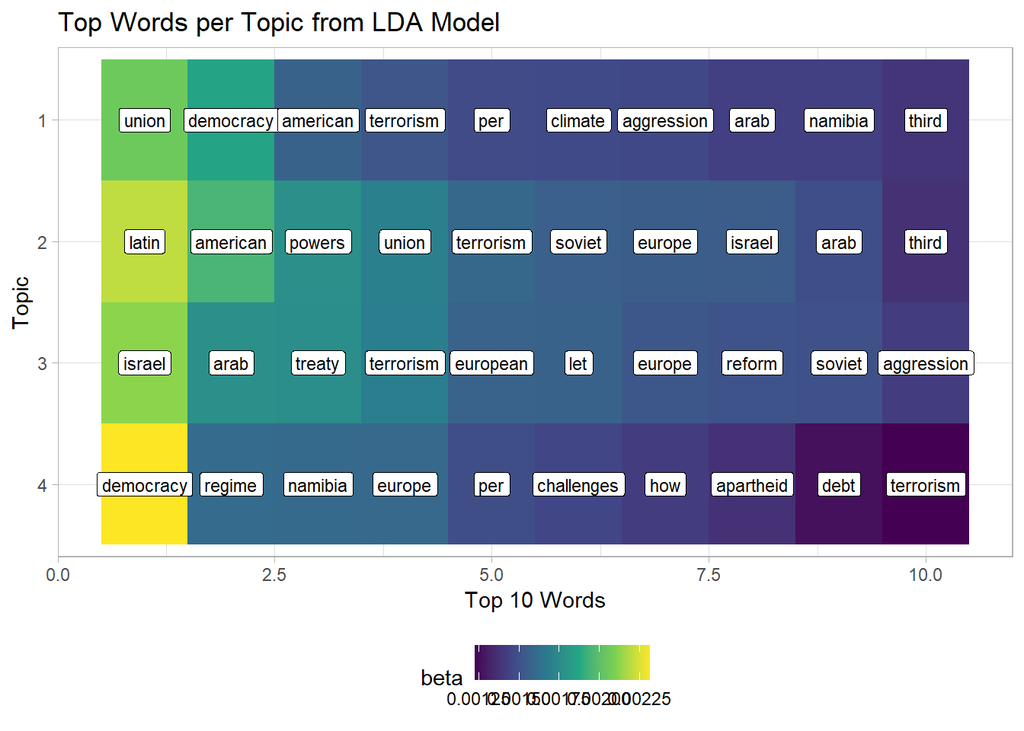

This graph shows the top 10 words for each topic discovered by the LDA model.

Each row represents a topic found in the speeches that mention Latin America.

The words inside each row are the most important for that topic — meaning they appear most often in the speeches grouped under that theme.

The colors show how strong or dominant each word is within its topic: brighter colors = more importance.

Some examples:

Topic 1 includes words like union, democracy, terrorism, and climate — which suggests this topic could be about international cooperation and global challenges.

Topic 2 includes latin, american, powers, and soviet — possibly connected to geopolitical influence and Cold War themes.

Topic 3 has terms like israel, arab, treaty, and reform — hinting at topics involving Middle East politics or peace processes.

Topic 4 contains democracy, regime, apartheid, and debt — suggesting a theme related to political systems and human rights.

This kind of analysis helps us move beyond just word counts; in fact, it shows what themes or narratives are being discussed when Latin America comes up in UN speeches.

## 2.5 GPT based interpretation

After identifying the main topics in the speeches using LDA, I wanted to better understand what each of those topics actually meant. Just looking at the top words is helpful, but not always easy to interpret clearly.

Hence, I used GPT API to analyze the top 10 words from each topic and summarize what they are really about. I asked GPT to tell me the overall tone (positive, negative, or neutral), and whether each topic focused more on opportunity, crisis, development, or conflict.

This step helped me translate the data into a more real and understandable way, and see how Latin America is framed in different ways across UN speeches.

*Topic 1*

[output not shown]

*Topic 2*

[output not shown]

*Topic 3*

[output not shown]

*Topic 4*

[output not shown]

This approach helped me understand more clearly how Latin America is framed in UN speeches. In fact, Latin America is often perceived as a region marked by political and social challenges, but also as a space for cooperation and international engagement. Sometimes it is framed within broader global dynamics, like the Cold War or international security, while in other cases it appears as a region in need of attention on issues such as democracy, human rights, and development.

# 3 Who is Framing Latin America?

Now I wanted to understand which countries are most engaged in discussing Latin America.

## 3.1 Bar Plot of Speaker Countries

The following bar plot shows who is shaping the international narrative about Latin America

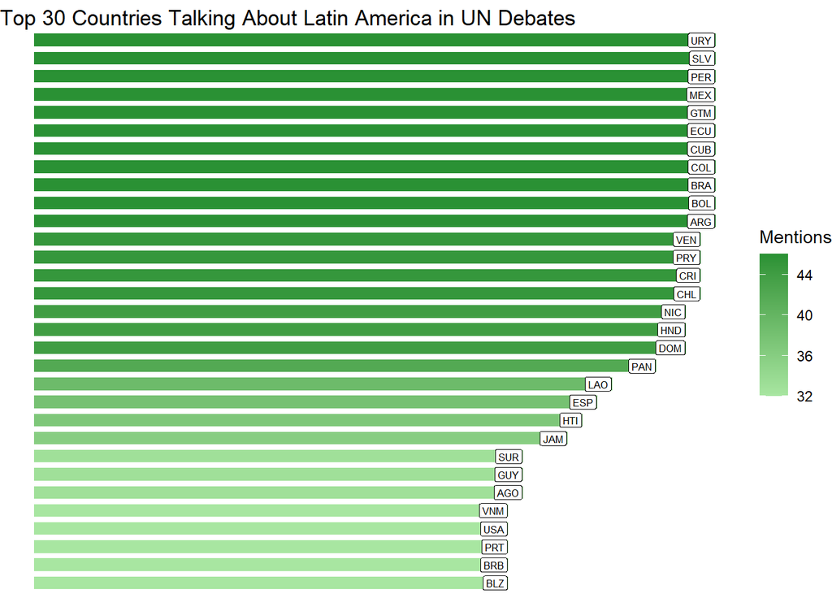

After identifying which countries talk the most about Latin America, I wanted to explore how this attention has evolved over time. Is the region consistently discussed, or are there specific moments when it receives more focus in UN speeches?

## 3.2 How Has This Changed Over Time?

Now, to see how this attention has shifted over the years, I grouped the speeches by year and looked at how often Latin America was mentioned each year.

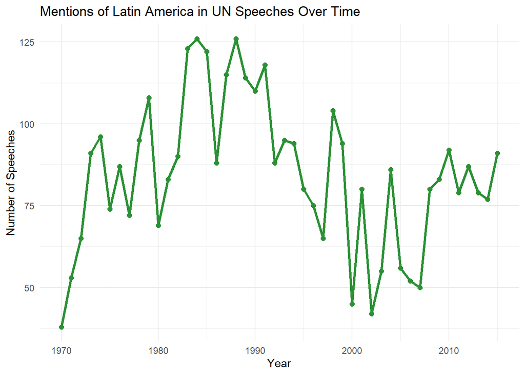

We can now observe how Latin America fades in and out of global debates.

This line chart shows how frequently Latin America was mentioned in speeches at the United Nations General Debate, year by year from the early 1970s through 2015. The data suggest that Latin America was a prominent topic during the Cold War era (e.g., due to U.S.–Soviet interest in the region, revolutions, debt crisis). Mentions dropped in later decades, possibly due to changing geopolitical priorities.

# 4 Conclusion

This project gave me the chance to explore how Latin America is perceived in UN General Debate speeches. I didn’t just look at how often the region is mentioned, but also how it’s talked about and what kind of narratives are associated with it.

What I learned is that Latin America is often seen as a region dealing with political and economic challenges, like issues of governance, debt, or security. But it’s also described as a place for international cooperation, especially when it comes to topics like peace, democracy, and development. In some speeches, the region is connected to broader global tensions, such as Cold War dynamics or international conflicts, which shows how external powers can influence the way Latin America is represented.

# 5 Appendix

## 5.1 Visualization

```r
library(tidyverse)
library(maps)

mentions <- read_csv("C:/Users/rubi2/OneDrive - John Cabot University/Desktop/PL-CS/Final project/new dataset/latin_america_mentions.csv")

# Here, I adjusted Dominican Republic to match the map's naming format
mentions$country[mentions$country == "Dominican Republic"] <- "Dominican Rep."

latin_america <- c(
  "Argentina", "Bolivia", "Brazil", "Chile", "Colombia", "Costa Rica", "Cuba",
  "Dominican Rep.", "Ecuador", "El Salvador", "Guatemala", "Honduras",
  "Mexico", "Nicaragua", "Panama", "Paraguay", "Peru", "Uruguay", "Venezuela"
)

world_map <- map_data("world")

map_mentions <- world_map %>%
  filter(region %in% latin_america) %>%
  left_join(mentions, by = c("region" = "country")) %>%
  mutate(mentions = replace_na(mentions, 0))

ggplot(map_mentions, aes(x = long, y = lat, group = group, fill = mentions)) +
  geom_polygon(color = "white", linewidth = 0.3) +
  coord_fixed(1.3) +
  scale_fill_gradient(low = "lightblue", high = "darkblue") +
  theme_void() +
  labs(title = "Mentions of Latin American Countries in UN Speeches",
       fill = "Mentions")
```

## 5.2 Mentions Bar Plot

```r
library(tidyverse)

mentions <- read_csv("C:/Users/rubi2/OneDrive - John Cabot University/Desktop/PL-CS/Final project/new dataset/latin_america_mentions.csv")
mentions$country[mentions$country == "Dominican Republic"] <- "Dominican Rep."

ggplot(mentions, aes(x = reorder(country, mentions), y = mentions, fill = mentions)) +
  geom_col() +
  geom_text(aes(label = country), hjust = 1.1, color = "white", size = 3.5) +
  coord_flip() +
  scale_fill_gradient(low = "lightblue", high = "darkblue") +
  theme_void() +
  labs(title = "Mentions of Latin American Countries in UN Speeches", fill = "Mentions")
```

## 5.3 Top 30 most common words in UN speeches about Latin America

```r
library(tidyverse)

top_words <- read_csv("C:/Users/rubi2/OneDrive - John Cabot University/Desktop/PL-CS/Final project/new dataset/top_words_latin_speeches.csv")

ggplot(top_words, aes(x = reorder(word, frequency), y = frequency, fill = frequency)) +
  geom_col() +
  coord_flip() +
  scale_fill_gradient(low = "lightblue", high = "darkblue") +
  theme_light() +
  labs(title = "Top 30 Words in Speeches About Latin America",
       x = "Word", y = "Frequency")
```

## 5.4 Wordcloud

```r
library(tidyverse)
library(quanteda)
library(quanteda.textplots)

# Load filtered speeches
latin_df <- read_csv("latin_df_filtered.csv")

# Combine all text into one string
latin_text <- paste(latin_df$text, collapse = " ")

# Create corpus
corpus_latam <- corpus(latin_text)

# Tokenize and clean
tokens_latam <- tokens(corpus_latam,
                       remove_punct = TRUE,
                       remove_numbers = TRUE) %>%
  tokens_remove(pattern = stopwords("english"))

dfm_latam <- dfm(tokens_latam)

# Plot wordcloud
textplot_wordcloud(dfm_latam, max_words = 100)
```

## 5.5 Sentiment over time

```python
from textblob import TextBlob
import pandas as pd

# Load the filtered speeches
latin_df = pd.read_csv("latin_df_filtered.csv")

# Apply TextBlob sentiment polarity
latin_df["sentiment"] = latin_df["text"].apply(lambda text: TextBlob(text).sentiment.polarity)

latin_df.to_csv("latin_df_with_sentiment.csv", index=False)
```

```r
library(tidyverse)

sentiment_data <- read_csv("latin_df_with_sentiment.csv")

# Average sentiment per year
sentiment_by_year <- sentiment_data %>%
  group_by(year) %>%
  summarise(avg_sentiment = mean(sentiment, na.rm = TRUE))

ggplot(sentiment_by_year, aes(x = year, y = avg_sentiment)) +
  geom_line(color = "#2a9134", size = 1.2) +
  geom_point(color = "#2a9134", size = 2) +
  theme_light() +
  labs(
    title = "Sentiment Over Time: UN Speeches on Latin America",
    x = "Year", y = "Average Sentiment Score"
  )
```

## 5.6 Top Modeling LDA

```python
import pandas as pd
import re
from gensim import corpora
from gensim.models.ldamodel import LdaModel

# Load filtered speeches
latin_df = pd.read_csv("latin_df_filtered.csv")

# Preprocess text
latin_df["processed"] = latin_df["text"].apply(lambda x: re.sub(r'[^a-z\s]', '', x.lower()).split())

# Build dictionary and corpus
dictionary = corpora.Dictionary(latin_df["processed"])
dictionary.filter_extremes(no_below=10, no_above=0.5)
corpus = [dictionary.doc2bow(text) for text in latin_df["processed"]]

# Train LDA model
lda = LdaModel(corpus=corpus, id2word=dictionary, num_topics=4, random_state=42)

# Get top terms per topic
top_terms = []
for topic_id in range(lda.num_topics):
    for term, prob in lda.show_topic(topic_id, topn=10):
        top_terms.append((topic_id + 1, term, prob))

# Format and save to CSV
top_terms_df = pd.DataFrame(top_terms, columns=["topic", "term", "beta"])
top_terms_df["rank"] = top_terms_df.groupby("topic")["beta"].rank("dense", ascending=False)

top_terms_df.to_csv("top_terms_lda.csv", index=False)
```

```r
library(tidyverse)

result_df <- read_csv("top_terms_lda.csv")

ggplot(result_df, aes(y = reorder(topic, -topic), x = rank)) +
  geom_tile(aes(fill = beta)) +
  scale_fill_viridis_c() +
  geom_label(aes(label = term), fill = "white", size = 3) +
  labs(title = "Top Words per Topic from LDA Model",
       y = "Topic", x = "Top 10 Words") +
  theme_light() +
  theme(legend.position = "bottom")
```

## 5.7 Bar Plot of Speaker Countries

```r
library(tidyverse)

speakers <- read_csv("C:/Users/rubi2/OneDrive - John Cabot University/Desktop/PL-CS/Final project/new dataset/speakers_about_latam.csv")

top_speakers <- speakers %>%
  arrange(desc(mentions)) %>%
  slice_max(order_by = mentions, n = 30)

ggplot(top_speakers, aes(x = reorder(country, mentions), y = mentions, fill = mentions)) +
  geom_col(width = 0.7) +
  geom_label(aes(label = country),
             fill = "white", color = "black",
             size = 2.2, hjust = 1.05) +
  coord_flip() +
  scale_fill_gradient(low = "#a8e6a1", high = "#2a9134") +
  theme_void() +
  labs(title = "Top 30 Countries Talking About Latin America in UN Debates", fill = "Mentions")
```

## 5.8 Change over time

```python
mentions_by_year = latin_df.groupby("year").size().reset_index(name="mentions")
mentions_by_year.to_csv("C:/Users/rubi2/OneDrive - John Cabot University/Desktop/PL-CS/Final project/new dataset/mentions_over_time.csv", index=False)
```

```r
mentions_time <- read_csv("C:/Users/rubi2/OneDrive - John Cabot University/Desktop/PL-CS/Final project/new dataset/mentions_over_time.csv")

ggplot(mentions_time, aes(x = year, y = mentions)) +
  geom_line(color = "#2a9134", size = 1.2) +
  geom_point(color = "#2a9134", size = 2) +
  theme_minimal() +
  labs(
    title = "Mentions of Latin America in UN Speeches Over Time",
    x = "Year", y = "Number of Speeches"
  )
```